# Uso de IA, sueño y rendimiento académico en estudiantes de UTEC

- Mostrar todo el código
- Ocultar todo el código
- Ver el código fuente

PG2 — Informe | Estadística y Probabilidades, sección 01, ciclo 2026-2

Autor/a

S1-G6

Fecha de publicación

23 de octubre de 2026

# 1 Introducción

## 1.1 Relevancia

Este tema es importante porque la mayoría de estudiantes usa la IA diariamente para sus actividades académicas. Analizar este uso nos ayuda a saber con qué frecuencia la utilizan, para qué la usan y en qué cursos hacen más consultas. También nos permite ver si el uso de esta herramienta realmente les ayuda a comprender mejor los temas o a ahorrar tiempo. Además, consideraremos otros factores asociados a hábitos de los estudiantes, como las horas de sueño y horas efectivas de estudio, para determinar su influencia en el rendimiento académico.

## 1.2 Planificación

### 1.2.1 Diagrama de Gantt

**Código**

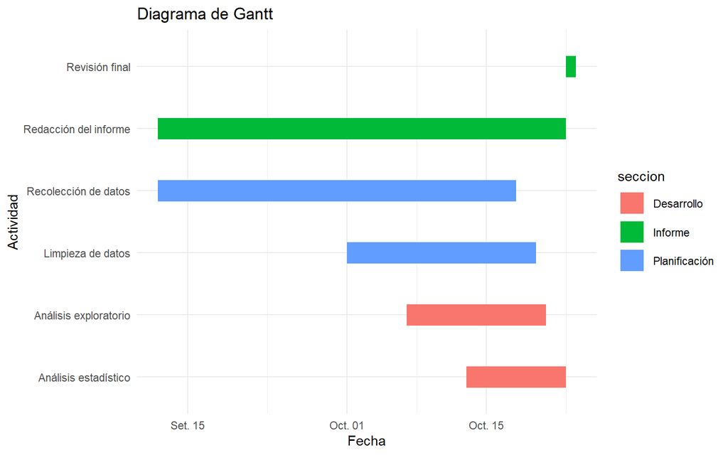

```r
library(ggplot2)

tareas <- data.frame(
  tarea = c(
    "Recolección de datos",
    "Limpieza de datos",
    "Análisis exploratorio",
    "Análisis estadístico",
    "Redacción del informe",
    "Revisión final"
  ),
  inicio = as.Date(c(
    "2026-09-12", "2026-10-01", "2026-10-07", "2026-10-13", "2026-09-12", "2026-10-23"
  )),
  fin = as.Date(c(
    "2026-10-18", "2026-10-20", "2026-10-21", "2026-10-23", "2026-10-23", "2026-10-24"
  )),
  seccion = c(
    "Planificación",
    "Planificación",
    "Desarrollo",
    "Desarrollo",
    "Informe",
    "Informe"
  )
)

ggplot(tareas,
       aes(x = inicio,
           xend = fin,
           y = tarea,
           yend = tarea,
           color = seccion)) +
  geom_segment(linewidth = 8) +
  labs(title = "Diagrama de Gantt",
       x = "Fecha",
       y = "Actividad") +
  theme_minimal()
```

## 1.3 Objetivos

### 1.3.1 Objetivo general

Analizar el impacto de las horas de sueño y el uso de IA en el rendimiento académico de los estudiantes UTEC de Estadística sección 1 durante el ciclo 2026-2.

### 1.3.2 Objetivos específicos

1. Analizar la existencia de alguna relación entre la frecuencia diaria de consultas a la IA y el Nivel de satisfacción con el avance académico diario.
2. Analizar si existe alguna correlación entre el número de consultas a la IA en un cierto día y la cantidad de horas dedicadas al estudio.
3. Identificar si el curso de mayor consulta influye en el principal uso que se le da a la Inteligencia Artificial ese día y determinar qué usos generan mayor número de tareas con tiempo ahorrado.
4. Determinar si existe una relación entre las horas de sueño de la noche anterior y el nivel de comprensión de las actividades académicas realizadas durante el día.

# 2 Datos

## 2.1 Población objetivo

Estudiantes universitarios de UTEC durante el semestre 2026-2 que cursan la materia de Estadística y Probabilidades de la sección 01.

### 2.1.1 Unidad muestral

Conformada por los estudiantes universitarios evaluados de forma individual y diaria. A cada uno de ellos se le aplicará un registro de datos para medir su comportamiento diario, su rendimiento académico y su relación con el uso de IA (en la tabla principal).

Además se contará con dos tablas externas: la “Tabla Exámenes”, cuya unidad muestral es cada examen rendido, y la “Tabla Demográfica”, con los datos invariantes del ciclo y cuya unidad muestral es cada estudiante.

### 2.1.2 Representatividad de la muestra

Con la finalidad de que la muestra obtenida refleje a la población y se minimicen posibles sesgos, se plantean las siguientes medidas:

Cobertura total de la sección: El instrumento de medición se aplicará en un aula específica, de modo que todos los integrantes contarán con acceso diario al formulario y así evitando el sesgo de no respuesta

Medición al cierre del día: El cuestionario se realizará al final de cada día el cual permitirá registrar las variables diarias (como las horas de estudio o el uso de IA), atenuando el sesgo de memoria. El registro de un día se contará como válido si este se hace después de las 9:30 p.m. pero antes de la medianoche.

## 2.2 Tipo de muestreo

Se utilizará un muestreo sistemático por conveniencia, estructurado bajo un diseño de recolección de datos de tipo longitudinal. Esta decisión responde a la exigencia del estudio, el cual requiere que los estudiantes reporten sus métricas académicas, de sueño y de uso de Inteligencia Artificial de forma diaria. El diseño longitudinal genera observaciones repetidas por estudiante, lo que permite capturar patrones de comportamiento en el tiempo.

## 2.3 Recolección de datos

Se diseñaron 3 formularios en Google Forms: demográfico (una vez por estudiante), diario (una vez por día) y de exámenes (uno por examen). Enlaces: [formulario diario](https://docs.google.com/forms/d/e/1FAIpQLSf9LZ3tyLEgC4oDca7NH8S9Zh-StC2w6ukAMH6yRnJej6tVzQ/viewform), [formulario demográfico](https://docs.google.com/forms/d/e/1FAIpQLSeTo6X7RJB_Jq6qrQ4By-Qrbfe_6qafpZ0N9gP62h2pQwOmlA/viewform), [formulario de exámenes](https://docs.google.com/forms/d/e/1FAIpQLScOFYt4wl2XJGtB4w-PzHCnRUiT-wfdmIg2zGpAUDZ_R_GAIA/viewform).

## 2.4 Variables

### 2.4.1 Consideración de los tipos de variables

| Variable | Tipo general | Subtipo |
| --- | --- | --- |
| N° de consultas a IA realizadas ese día | Cuantitativa | Discreta |
| Principal uso de IA ese día | Cualitativa | Nominal |
| Nivel de satisfacción con el avance académico diario | Cualitativa | Ordinal |
| N° de tareas ese día en las que usar IA le ahorró tiempo | Cuantitativa | Discreta |
| curso sobre el cual se hicieron la mayoría de consultas de IA | Cualitativa | Nominal |
| Suma de horas efectivas de estudio | Cuantitativa | Continua |
| Horas de sueño de la noche anterior | Cuantitativa | Continua |
| Nivel de comprensión de las actividades académicas realizadas ese día | Cualitativa | Ordinal |

### 2.4.2 Libreta de códigos

| Variable | Restricción / Rango o categorías válidas |
| --- | --- |
| N° consultas a IA realizada ese día | x >= 0 |
| Nivel de satisfacción con el avance académico diario | Likert de 5 niveles, codificado de 1 a 5 |
| Suma de horas efectivas de estudio | x >= 0 |
| curso sobre el cual se hicieron la mayoría de consultas de IA | Código de curso UTEC, formato XX#### |
| Principal uso de IA ese día | resumir, resolver ejercicios, redactar, programar, otros |
| N° de tareas ese día en las que usar IA le ahorró tiempo | x >= 0 |
| Horas de sueño de la noche anterior | 0 <= x <= 24 |
| Nivel de comprensión de las actividades académicas realizadas ese día | Muy bajo, Bajo, Moderado, Alto, Muy alto |

### 2.4.3 Mediciones

Cada variable va a ser registrada en el formulario de Google Forms, el cual contendrá todas las restricciones de valores que puede tomar la variable dependiendo de su tipo y de su naturaleza.

## 2.5 Limpieza

### 2.5.1 Paso 0: Obtener el conjunto de datos

**Código**

```r
library(readr)
library(dplyr)
library(tidyverse)
library(ggplot2)

DF <- read_csv("RespuestasDiario.csv")
```

**Código**

```r
names(DF)
```

```
 [1] "Marca temporal"
 [2] "¿Cuántas consultas a una IA realizaste hoy?"
 [3] "¿Qué nivel de confianza tienes en las respuestas de la IA sin verificarlas?"
 [4] "¿Cuál fue el uso principal que le diste a la IA hoy?"
 [5] "¿Cuántas horas dormiste la noche pasada?"
 [6] "¿Con qué frecuencia estudiaste hoy?"
 [7] "¿A cuántas clases no asististe hoy?"
 [8] "¿Qué nivel de satisfacción tienes con tu avance académico de hoy?"
 [9] "¿Qué material utilizaste más para estudiar hoy?"
[10] "¿Cuántas horas dedicaste exclusivamente a trabajos grupales o proyectos hoy?"
[11] "¿Qué nivel de comprensión tuviste de las actividades académicas que realizaste hoy?"
[12] "¿Cuál fue tu sensación principal después de usar la IA hoy?"
[13] "¿En cuántas tareas de hoy el uso de la IA te ahorró tiempo?"
[14] "¿Cuál es el código del curso sobre el que hiciste la mayoría de tus consultas a la IA hoy?"
[15] "¿Cuántas horas efectivas de estudio acumulaste el día de hoy?"
[16] "Dirección de correo electrónico"
```

**Código**

```r
DFL <- DF
```

Renombramos las columnas de interés y las filtramos del resto de columnas.

**Código**

```r
DFL %>% rename(hora = `Marca temporal`
               , consultas = `¿Cuántas consultas a una IA realizaste hoy?`
               , uso = `¿Cuál fue el uso principal que le diste a la IA hoy?`
               , satisfaccion = `¿Qué nivel de satisfacción tienes con tu avance académico de hoy?`
               , tareas = `¿En cuántas tareas de hoy el uso de la IA te ahorró tiempo?`
               , curso = `¿Cuál es el código del curso sobre el que hiciste la mayoría de tus consultas a la IA hoy?`
               , estudio = `¿Cuántas horas efectivas de estudio acumulaste el día de hoy?`
               , sueno = `¿Cuántas horas dormiste la noche pasada?`
               , comprension = `¿Qué nivel de comprensión tuviste de las actividades académicas que realizaste hoy?`
               , email = `Dirección de correo electrónico`) -> DFL
```

**Código**

```r
DFL <- DFL[, c("hora", "consultas", "uso", "satisfaccion", "tareas", "curso", "estudio", "sueno", "comprension", "email")]
names(DFL)
```

```
 [1] "hora"         "consultas"    "uso"          "satisfaccion" "tareas"
 [6] "curso"        "estudio"      "sueno"        "comprension"  "email"
```

Obtenemos los grupos que han aportado en base a los correos que tenemos y en base a una tabla auxiliar

**Código**

```r
DFAuxiliar <- read_csv("CorreosGrupo.csv")
```

Realizamos un inner join para relacionar `email` con el grupo correspondiente

**Código**

```r
DFL <- inner_join(DFL, DFAuxiliar, by = "email")
```

### 2.5.2 Vista del subset final

**Código**

```r
dim(DFL)
```

```
[1] 498  11
```

**Código**

```r
head(DFL)
```

```
# A tibble: 6 × 11
  hora       consultas uso   satisfaccion tareas curso estudio sueno comprension
  <chr>          <dbl> <chr>        <dbl>  <dbl> <chr>   <dbl> <dbl> <chr>
1 12/09/202…         9 Resu…            4      1 CS40…       3  9    Alto
2 12/09/202…         0 El d…            3      2 ME20…       1  5    Moderado
3 12/09/202…        13 Resu…            3      1 CS40…       3  9    Alto
4 12/09/202…         2 Inve…            4      1 CS20…       4  8.33 Muy alto
5 12/09/202…         4 Resu…            3      1 GI31…       1  8    Moderado
6 12/09/202…        32 Resu…            3      0 CS20…       7  7    Moderado
# ℹ 2 more variables: email <chr>, Grupo <dbl>
```

**Código**

```r
sapply(DFL, class)
```

```
        hora    consultas          uso satisfaccion       tareas        curso
 "character"    "numeric"  "character"    "numeric"    "numeric"  "character"
     estudio        sueno  comprension        email        Grupo
   "numeric"    "numeric"  "character"  "character"    "numeric"
```

### 2.5.3 Paso 1: Radiografía de la base

Cantidad de NA por columna:

**Código**

```r
colSums(is.na(DFL))
```

```
        hora    consultas          uso satisfaccion       tareas        curso
           0            0            2            0            0            2
     estudio        sueno  comprension        email        Grupo
           0            0            0            0            0
```

Porcentaje de NA por columna:

**Código**

```r
round(colSums(is.na(DFL)) / nrow(DFL) * 100, 2)
```

```
        hora    consultas          uso satisfaccion       tareas        curso
         0.0          0.0          0.4          0.0          0.0          0.4
     estudio        sueno  comprension        email        Grupo
         0.0          0.0          0.0          0.0          0.0
```

Se puede ver que hay 4 valores faltantes en el dataframe. Esto es raro considerando que el formulario original tiene todas las preguntas marcadas como obligatorias.

#### 2.5.3.1 Análisis de ceros

**Código**

```r
sum(DFL$consultas == 0, na.rm = TRUE)
```

```
[1] 39
```

Hay 39 registros en los que el estudiante no consultó la IA en todo el día.

**Código**

```r
sum(DFL$tareas == 0, na.rm = TRUE)
```

```
[1] 109
```

Hay 109 registros en los que la IA no ahorró tiempo en ninguna tarea.

**Código**

```r
sum(DFL$estudio == 0, na.rm = TRUE)
```

```
[1] 32
```

Hay 32 registros de personas que no estudiaron ni una hora durante 1 día.

**Código**

```r
sum(DFL$sueno == 0, na.rm = TRUE)
```

```
[1] 7
```

Hay 7 registros de estudiantes que no durmieron ni 1 hora.

#### 2.5.3.2 Análisis de cardinalidad

**Código**

```r
unique(DFL$comprension)
```

```
[1] "Alto"     "Moderado" "Muy alto" "Bajo"     "Muy bajo"
```

La ordinal `comprension` ya tomó sus 5 niveles al menos una vez.

**Código**

```r
length(unique(DFL$sueno))
```

```
[1] 33
```

**Código**

```r
unique(DFL$sueno)
```

```
 [1]  9.0000  5.0000  8.3300  8.0000  7.0000 10.0000  6.0000  8.1600  4.0000
[10]  3.0000  7.5000  7.6600  6.6600  6.5000  3.5000 13.0000  8.5000  2.0000
[19]  8.4500 11.0000  7.6555  4.1700  4.5000  9.8000  0.0000  9.4000  1.0000
[28]  8.2000 10.5000 14.0000  7.1700  7.8300  9.6000
```

Las variables `sueno` y `estudio` toman valores diversos pese a su discretización parcial y al rango admisible reducido [0, 24].

**Código**

```r
length(unique(DFL$estudio))
```

```
[1] 31
```

**Código**

```r
unique(DFL$estudio)
```

```
 [1]  3.00  1.00  4.00  7.00  2.00  0.00  3.70  9.00  5.00  1.20  6.00  1.50
[13]  0.66  4.20  2.83  1.58  2.42  0.50  5.20  3.50  2.33  1.17  8.00 13.00
[25]  2.50 10.00  2.30  5.83  5.33  4.33  5.08
```

**Código**

```r
length(unique(DFL$curso))
```

```
[1] 97
```

`curso` varía mucho porque la UTEC dicta varios cursos y los alumnos vienen de distintas carreras.

**Código**

```r
length(unique(DFL$tareas))
```

```
[1] 13
```

**Código**

```r
sort(unique(DFL$tareas))
```

```
 [1]  0  1  2  3  4  5  6  7  8 11 12 13 15
```

La variable discreta `tareas` ha tomado una cantidad reducida de valores encerrados en el intervalo [0, 15].

**Código**

```r
unique(DFL$satisfaccion)
```

```
[1] 4 3 1 2 5
```

La ordinal `satisfaccion` también tomó sus 5 niveles.

**Código**

```r
length(unique(DFL$uso))
```

```
[1] 43
```

**Código**

```r
unique(DFL$uso)
```

```
 [1] "Resumir"                      "El día de hoy no usé IA"
 [3] "Investigar"                   "Agendara recordatorio"
 [5] "Revisar conceptos"            "Ninguno"
 [7] "No la usé"                    "Resolver ejercicios"
 [9] "Programar"                    "No use ia hoy"
[11] "profundizar conceptos"        "Consultar"
[13] "Redactar"                     "Traducir y entender idiomas"
[15] "investigar temas"             "consulta medica"
[17] "No usé"                       "Buscar herramientas"
[19] "Ayudarme a encontrar errores" "revisar conceptos"
[21] "no lo use"                    NA
[23] "Nada"                         "Ninguna"
[25] "No use IA"                    "repasar"
[27] "Ayudar a aprender"            "Aprender"
[29] "Una pregunta al azar"         "No usé IA"
[31] "Repasar"                      "Explicar temas"
[33] "Traducir"                     "No use idea"
[35] "Aprender inglés"              "nothing"
[37] "preguntas de conceptos"       "Dudas cotidianas"
[39] "-"                            "Buscar informacion"
[41] "No use"                       "investigar"
[43] "0"
```

La nominal `uso` presenta gran variabilidad, propia de su naturaleza.

**Código**

```r
length(unique(DFL$consultas))
```

```
[1] 55
```

La discreta `consultas` también presenta una gran cantidad de valores únicos.

### 2.5.4 Paso 2: Normalización

Se filtrará con base en el plazo de tiempo para el envío del formulario. Además, se tendrán en cuenta los valores que pudieron evadir las restricciones iniciales, por lo que se aplicarán verificaciones de valores vacíos en las columnas de consultas, tareas, estudio y sueno, junto con la validación de valores enteros.

**Código**

```r
#Se hace el filtrado por horas teniendo en cuenta que se guarda en el formato de 24 horas por lo que solo acotamos desde 21.5 o sea 9:30

DFL1<-DFL%>%filter(!(((hour(dmy_hms(hora)) + minute(dmy_hms(hora))/60) < 21.5))) %>%

# en caso de superesswarnings es para evitar que arroje errores en consultas debido a que permite ingreso de datos vacíos por lo que se trata de convertir a numero y de ahí vemos si es NA e invirtiendo mediante ! para quedarnos con los que si cumplan eso

filter(!is.na(suppressWarnings(as.numeric(consultas))),

# Repetimos el mismo tipo de filtrado con respecto a la variable tareas, sueno y estudio

!is.na(suppressWarnings(as.numeric(tareas))),
!is.na(suppressWarnings(as.numeric(estudio))),                           !is.na(suppressWarnings(as.numeric(sueno))))%>%

#verificamos que las consultas y tareas sean números enteros

filter(as.numeric(consultas)%%1==0,
       as.numeric(tareas)%%1==0)
```

### 2.5.5 Paso 3: Aplicación de criterios (validación de rangos)

Como la respuesta cualitativa (uso) se relaciona con variables cuantitativas (consultas y tareas), para evitar la pérdida de la fila debido a los datos contradictorios, los valores no válidos se reasignarán con NA.

**Código**

```r
  DF2<-DFL1%>%mutate(

  # se arma el primer filtro para normalizar uso
  uso_= chartr("áéíóúÁÉÍÓÚ", "aeiouAEIOU", tolower(uso)),

  # el segundo filtro para la búsqueda de palabras clave
  usoC= str_detect(uso_,regex("\\b(ia|no|use|ningun[oa])\\b",ignore_case = TRUE)),

  # el tercer filtro ayuda a buscar datos no validos y validar los mismos
  cursoC = is.na(curso) | str_detect(curso, "^[ -]*$") |
  str_detect(curso, "^[A-Za-z]{2}\\d{4}$"),

  # el cuarto filtro verifica las consultas y une con validacion de curso
  filtro=!usoC&cursoC&(as.numeric(consultas)>0|as.numeric(tareas)>0),

  # se aplica el filtro para cada dato relacionado
  uso = if_else(filtro, uso,NA_character_),

  consultas=if_else(filtro,consultas,NA_integer_),

  tareas= if_else(filtro,tareas,NA_integer_),

  curso = if_else(filtro,curso,NA_character_)
  ) %>% select(-filtro, -usoC,-cursoC,-uso_)
# después se borra las columnas auxiliares
DF2$curso<-toupper(DF2$curso)
DF2$uso<-tolower(DF2$uso)
```

### 2.5.6 Paso 4: Datos atípicos

Para identificar posibles valores atípicos utilizamos boxplots en las variables numéricas.

**Código**

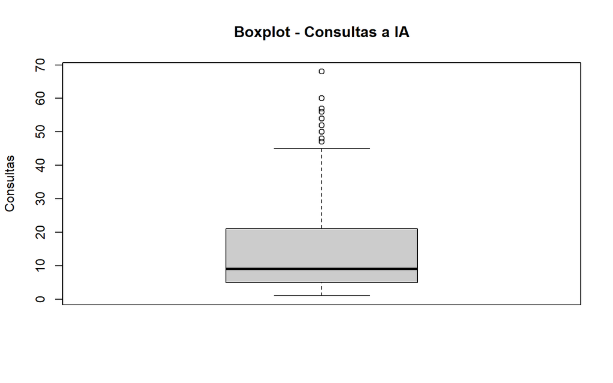

```r
# Número de consultas a IA
boxplot(DF2$consultas,
        main = "Boxplot - Consultas a IA",
        ylab = "Consultas",
        col = "gray80")
```

**Código**

```r
boxplot.stats(DF2$consultas)$out
```

```
 [1] 68 50 50 54 48 56 50 57 52 47 60 47 54
```

**Código**

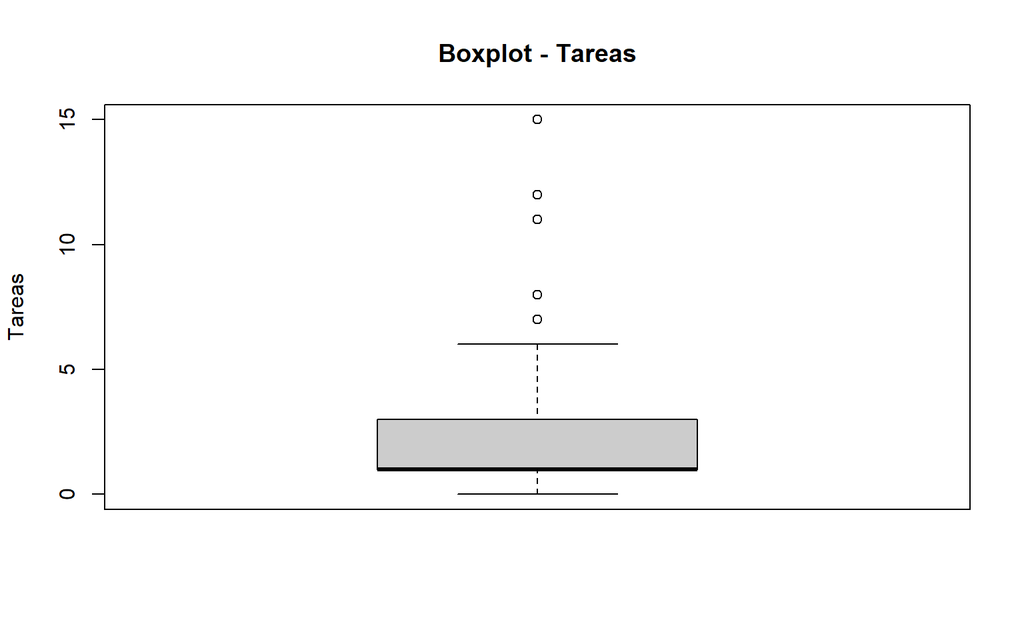

```r
# Número de tareas donde la IA ahorró tiempo
boxplot(DF2$tareas,
        main = "Boxplot - Tareas",
        ylab = "Tareas",
        col = "gray80")
```

**Código**

```r
boxplot.stats(DF2$tareas)$out
```

```
[1] 15  7 11 12 11  8  8
```

**Código**

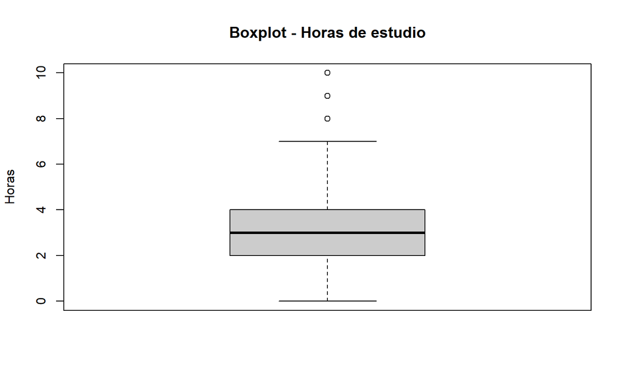

```r
# Horas efectivas de estudio
boxplot(DF2$estudio,
        main = "Boxplot - Horas de estudio",
        ylab = "Horas",
        col = "gray80")
```

**Código**

```r
boxplot.stats(DF2$estudio)$out
```

```
[1]  9  8  8  8  8  8  9 10  8
```

**Código**

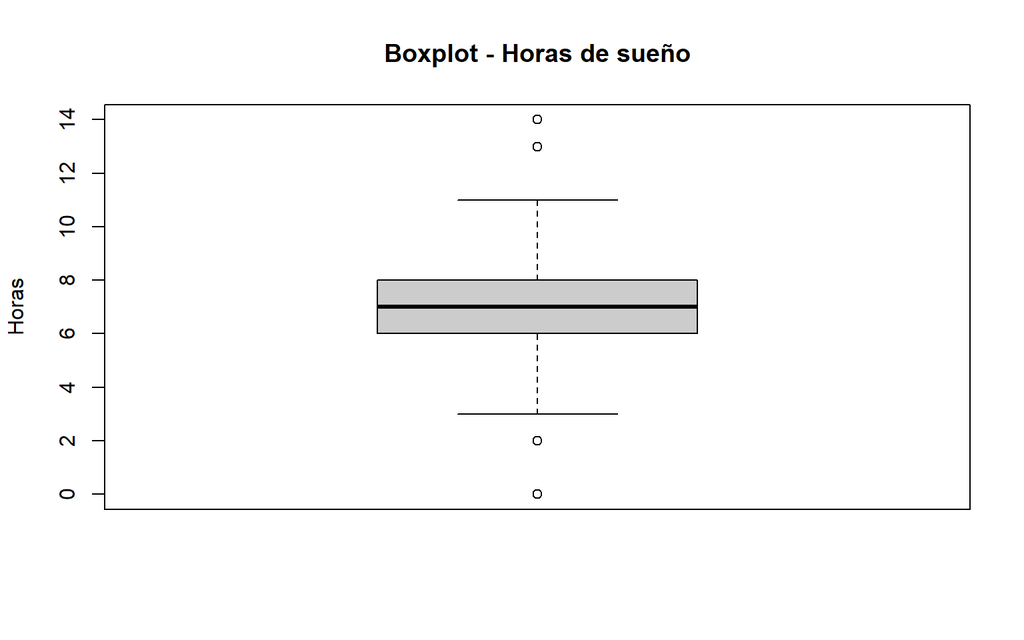

```r
# Horas de sueño
boxplot(DF2$sueno,
        main = "Boxplot - Horas de sueño",
        ylab = "Horas",
        col = "gray80")
```

**Código**

```r
boxplot.stats(DF2$sueno)$out
```

```
 [1] 13  2  2  2  2  0  0  0 14 14  0  0  0  0
```

### 2.5.7 Paso 5: Variabilidad

Para cada una de las variables numéricas calculamos el rango, la varianza, la desviación estándar, el IQR y el coeficiente de variación (CV). Si el CV es mayor a 0.6 usamos la mediana como medida central; si no, la media.

**Código**

```r
# Variabilidad de las consultas
range(DF2$consultas, na.rm = TRUE)
```

```
[1]  1 68
```

**Código**

```r
var(DF2$consultas, na.rm = TRUE)
```

```
[1] 188.0018
```

**Código**

```r
sd(DF2$consultas, na.rm = TRUE)
```

```
[1] 13.71138
```

**Código**

```r
IQR(DF2$consultas, na.rm = TRUE)
```

```
[1] 16
```

**Código**

```r
sd(DF2$consultas, na.rm = TRUE) / mean(DF2$consultas, na.rm = TRUE)
```

```
[1] 0.926587
```

**Código**

```r
# Variabilidad de las tareas
range(DF2$tareas, na.rm = TRUE)
```

```
[1]  0 15
```

**Código**

```r
var(DF2$tareas, na.rm = TRUE)
```

```
[1] 3.545999
```

**Código**

```r
sd(DF2$tareas, na.rm = TRUE)
```

```
[1] 1.883082
```

**Código**

```r
IQR(DF2$tareas, na.rm = TRUE)
```

```
[1] 2
```

**Código**

```r
sd(DF2$tareas, na.rm = TRUE) / mean(DF2$tareas, na.rm = TRUE)
```

```
[1] 0.9939277
```

**Código**

```r
# Variabilidad de las horas de estudio
range(DF2$estudio, na.rm = TRUE)
```

```
[1]  0 10
```

**Código**

```r
var(DF2$estudio, na.rm = TRUE)
```

```
[1] 3.488978
```

**Código**

```r
sd(DF2$estudio, na.rm = TRUE)
```

```
[1] 1.867881
```

**Código**

```r
IQR(DF2$estudio, na.rm = TRUE)
```

```
[1] 2
```

**Código**

```r
sd(DF2$estudio, na.rm = TRUE) / mean(DF2$estudio, na.rm = TRUE)
```

```
[1] 0.6133965
```

**Código**

```r
# Variabilidad de las horas de sueño
range(DF2$sueno, na.rm = TRUE)
```

```
[1]  0 14
```

**Código**

```r
var(DF2$sueno, na.rm = TRUE)
```

```
[1] 3.830852
```

**Código**

```r
sd(DF2$sueno, na.rm = TRUE)
```

```
[1] 1.957256
```

**Código**

```r
IQR(DF2$sueno, na.rm = TRUE)
```

```
[1] 2
```

**Código**

```r
sd(DF2$sueno, na.rm = TRUE) / mean(DF2$sueno, na.rm = TRUE)
```

```
[1] 0.2890451
```

**Código**

```r
# Frecuencia del principal uso de IA (de mayor a menor)
length(unique(na.omit(DF2$uso)))
```

```
[1] 18
```

**Código**

```r
head(sort(table(DF2$uso), decreasing = TRUE), 4)
```

```
resolver ejercicios             resumir           programar            redactar
                121                  98                  84                  27
```

**Código**

```r
round(head(sort(prop.table(table(DF2$uso)), decreasing = TRUE), 4) * 100, 2)
```

```
resolver ejercicios             resumir           programar            redactar
              34.47               27.92               23.93                7.69
```

**Código**

```r
# Frecuencia del nivel de satisfacción
table(DF2$satisfaccion)
```

```
  1   2   3   4   5
 30  35 194 125  32
```

**Código**

```r
prop.table(table(DF2$satisfaccion)) * 100
```

```
        1         2         3         4         5
 7.211538  8.413462 46.634615 30.048077  7.692308
```

**Código**

```r
# Frecuencia del nivel de comprensión (en su orden natural)
niveles <- c("Muy bajo", "Bajo", "Moderado", "Alto", "Muy alto")
table(factor(DF2$comprension, levels = niveles))
```

```
Muy bajo     Bajo Moderado     Alto Muy alto
      16       27      237      104       32
```

**Código**

```r
prop.table(table(factor(DF2$comprension, levels = niveles))) * 100
```

```
 Muy bajo      Bajo  Moderado      Alto  Muy alto
 3.846154  6.490385 56.971154 25.000000  7.692308
```

### 2.5.8 Paso 6: Gestión de nulos

Tras los filtros iniciales, los valores nulos (NA) se concentran en cuatro variables sobre IA. A continuación, se evalúa el impacto de una eliminación directa.

**Código**

```r
tabla_NA <- data.frame(
  Variable = names(DF2),
  Cantidad_NA = colSums(is.na(DF2)),
  Porcentaje_NA = round(colSums(is.na(DF2)) / nrow(DF2) * 100, 2),
  row.names = NULL
)
tabla_NA
```

```
       Variable Cantidad_NA Porcentaje_NA
1          hora           0          0.00
2     consultas          65         15.62
3           uso          65         15.62
4  satisfaccion           0          0.00
5        tareas          65         15.62
6         curso          65         15.62
7       estudio           0          0.00
8         sueno           0          0.00
9   comprension           0          0.00
10        email           0          0.00
11        Grupo           0          0.00
```

**Código**

```r
#Revisamos si los NAs están en una mismo registro
table(rowSums(is.na(DF2)))
```

```
  0   4
351  65
```

**Código**

```r
#Impacto si eliminamos los NAs
nrow(DF2)
```

```
[1] 416
```

**Código**

```r
nrow(na.omit(DF2))
```

```
[1] 351
```

**Código**

```r
round((1 - nrow(na.omit(DF2)) / nrow(DF2)) * 100, 2)
```

```
[1] 15.62
```

**Código**

```r
# DF2 sale de DFL1 sin filtrar filas, recuperamos de DFL1 los valores que el Paso 3 convirtió a NA
nrow(DFL1) == nrow(DF2)
```

```
[1] TRUE
```

**Código**

```r
diagnostico <- DF2 %>%
  mutate(
    # Valores originales, antes del Paso 3
    consultas_orig = as.numeric(DFL1$consultas),
    tareas_orig    = as.numeric(DFL1$tareas),
    uso_orig       = as.character(DFL1$uso),
    curso_orig     = as.character(DFL1$curso),

    # ¿El estudiante declaró alguna actividad con IA ese día?
    hubo_actividad = consultas_orig > 0 | tareas_orig > 0,

    # Motivo por el que el registro quedó incompleto
    motivo = case_when(
      !is.na(uso)     ~ "Completo",
      !hubo_actividad ~ "Sin uso de IA",
      consultas_orig == 0 & is.na(uso_orig) ~ "Sin uso de IA",
      TRUE            ~ "Curso fuera de formato"
    )
  )

table(diagnostico$motivo)
```

```
              Completo Curso fuera de formato          Sin uso de IA
                   351                     34                     31
```

Se identificaron dos mecanismos que exigen un tratamiento diferenciado para no sesgar los datos:

**Código**

```r
# Perfil de cada grupo según las consultas que realmente declararon
diagnostico %>%
  filter(motivo != "Completo") %>%
  group_by(motivo) %>%
  summarise(
    n = n(),
    consultas_min   = min(consultas_orig),
    consultas_max   = max(consultas_orig),
    consultas_media = round(mean(consultas_orig), 1)
  )
```

```
# A tibble: 2 × 5
  motivo                     n consultas_min consultas_max consultas_media
  <chr>                  <int>         <dbl>         <dbl>           <dbl>
1 Curso fuera de formato    34             0            30             6.3
2 Sin uso de IA             31             0             0             0
```

Una política uniforme asignaría `consultas = 0` y `uso = "No usó IA"` a estudiantes con uso intensivo, sesgando las variables centrales de los objetivos 1 y 3.

| Motivo | Tratamiento | Justificación |
| --- | --- | --- |
| Sin uso de IA | `consultas` y `tareas` → 0; `uso` → “No usó IA”; `curso` → “No aplica” | El valor real del conteo es cero y la ausencia es una respuesta lógica |
| Curso fuera de formato | Se conservan `consultas`, `tareas` y `uso`; solo `curso` → “Sin código válido” | El uso de IA sí ocurrió; lo único inválido es el código del curso |

Se agrega `uso_ia` para que los objetivos 1 y 3 puedan filtrar los días sin uso sin eliminarlos. También se codifican las variables ordinales como factor y los identificadores como nominales.

**Código**

```r
DF_GesNulos <- diagnostico %>%
  mutate(
    #Indicador de uso de IA, según el motivo y no según si había NA
    uso_ia = factor(if_else(motivo != "Sin uso de IA", "Usó IA", "No usó IA"),
                    levels = c("Usó IA", "No usó IA")),

    # Si no usó IA, el valor verdadero es 0
    # Cuantitativas discretas:
    consultas = if_else(motivo == "Sin uso de IA", 0, consultas_orig),
    consultas= as.integer(consultas),
    tareas    = if_else(motivo == "Sin uso de IA", 0, tareas_orig),
    tareas= as.integer(tareas),
    # Cualitativa nominal
    uso   = if_else(motivo == "Sin uso de IA", "No usó IA", uso_orig),
    uso = factor(uso,levels=unique(uso)),


  # Solo el curso se marca como inválido; el resto de datos se conserva
    curso = case_when(
      motivo == "Sin uso de IA"          ~ "No aplica",
      motivo == "Curso fuera de formato" ~ "Sin código válido",
      TRUE                               ~ curso_orig
    ),
      curso = factor(curso,levels=unique(curso)),

    # Cuantitativas continuas
    estudio = as.numeric(estudio),
    sueno   = as.numeric(sueno),

    # Ordinal con levels
    comprension = factor(comprension,
                         levels = c("Muy bajo", "Bajo", "Moderado", "Alto", "Muy alto"),
                         ordered = TRUE),

    satisfaccion = factor(satisfaccion, levels = 1:5, ordered = TRUE),

    # Identificador
    Grupo = factor(Grupo)
  ) %>%
# Se borran las columnas que solo sirvieron para el diagnóstico
  select(-consultas_orig, -tareas_orig, -uso_orig, -curso_orig,
         -hubo_actividad, -motivo)
```

**Código**

```r
# Verificamos que no quede ningún NA ni se hayan perdido filas
sum(is.na(DF_GesNulos))
```

```
[1] 0
```

**Código**

```r
nrow(DF_GesNulos)
```

```
[1] 416
```

**Código**

```r
table(DF_GesNulos$uso_ia)
```

```
   Usó IA No usó IA
      385        31
```

La base queda sin faltantes y sin pérdida de observaciones con cada faltante tratado según el mecanismo que lo originó.

Las columnas de control (`hora`, `email`, `Grupo`) quedan en `DF_GesNulos`, que usaremos en el Paso 7. A continuación creamos `DF3`, conservando únicamente las variables de los objetivos y `uso_ia`.

**Código**

```r
DF3 <- DF_GesNulos %>%
  select(consultas, uso, satisfaccion, tareas, curso,
         estudio, sueno, comprension, uso_ia)

    dim(DF3)
```

```
[1] 416   9
```

**Código**

```r
    sapply(DF3, function(x) class(x)[1])
```

```
   consultas          uso satisfaccion       tareas        curso      estudio
   "integer"     "factor"    "ordered"    "integer"     "factor"    "numeric"
       sueno  comprension       uso_ia
   "numeric"    "ordered"     "factor"
```

**Código**

```r
    sum(is.na(DF3))
```

```
[1] 0
```

**Base limpia y prolija: `DF3`**, sobre la que se desarrolla el análisis, sin valores faltantes y con cada variable en su tipo correcto (ordinales como factor ordenado, nominales como factor).

### 2.5.9 Paso 7: Radiografía final

**Código**

```r
# Cuántas observaciones sobreviven a cada etapa del proceso
trazabilidad <- data.frame(
  Etapa = c("Base cruda (DF)", "Subset y join (DFL)", "Normalización (DFL1)",
            "Criterios (DF2)", "Gestión de nulos (DF3)"),
  Observaciones = c(nrow(DF), nrow(DFL), nrow(DFL1), nrow(DF2), nrow(DF3))
)
# Qué porcentaje de la base original representa cada etapa
trazabilidad$Retencion <- round(trazabilidad$Observaciones / nrow(DF) * 100, 2)
trazabilidad
```

```
                   Etapa Observaciones Retencion
1        Base cruda (DF)           498    100.00
2    Subset y join (DFL)           498    100.00
3   Normalización (DFL1)           416     83.53
4        Criterios (DF2)           416     83.53
5 Gestión de nulos (DF3)           416     83.53
```

**Código**

```r
# Mismo diagnóstico del Paso 1, ahora sobre la base limpia.
radiografia <- data.frame(
  Variable = names(DF3),
  Tipo = sapply(DF3, function(x) class(x)[1]),
  NA_total = colSums(is.na(DF3)),
  Porcentaje_NA = round(colSums(is.na(DF3)) / nrow(DF3) * 100, 2),
  Unicos = sapply(DF3, function(x) length(unique(x))),
  row.names = NULL
)
radiografia
```

```
      Variable    Tipo NA_total Porcentaje_NA Unicos
1    consultas integer        0             0     54
2          uso  factor        0             0     24
3 satisfaccion ordered        0             0      5
4       tareas integer        0             0     12
5        curso  factor        0             0     46
6      estudio numeric        0             0     29
7        sueno numeric        0             0     32
8  comprension ordered        0             0      5
9       uso_ia  factor        0             0      2
```

**Código**

```r
# Conteo de ceros en cada numérica
sum(DF3$consultas == 0)
```

```
[1] 34
```

**Código**

```r
sum(DF3$tareas == 0)
```

```
[1] 97
```

**Código**

```r
sum(DF3$estudio == 0)
```

```
[1] 26
```

**Código**

```r
sum(DF3$sueno == 0)
```

```
[1] 7
```

La base final no presenta NAs. Los ceros representan días sin IA en `consultas` y `tareas`, jornadas sin estudio en `estudio`, y 0 horas declaradas en `sueno`. Las cualitativas mantienen su formato de factor ordenado y nominal.

**Código**

```r
# Verificamos que ninguna numérica se salga de los rangos del codebook.

data.frame(
  Variable = c("consultas", "tareas", "estudio", "sueno"),
  Restriccion = c("x >= 0", "x >= 0", "x >= 0", "0 <= x <= 24"),
  Minimo = c(min(DF3$consultas), min(DF3$tareas), min(DF3$estudio), min(DF3$sueno)),
  Maximo = c(max(DF3$consultas), max(DF3$tareas), max(DF3$estudio), max(DF3$sueno)),
  Cumple = c(all(DF3$consultas >= 0), all(DF3$tareas >= 0), all(DF3$estudio >= 0),
             all(DF3$sueno >= 0 & DF3$sueno <= 24))
)
```

```
   Variable  Restriccion Minimo Maximo Cumple
1 consultas       x >= 0      0     68   TRUE
2    tareas       x >= 0      0     15   TRUE
3   estudio       x >= 0      0     10   TRUE
4     sueno 0 <= x <= 24      0     14   TRUE
```

Todas las variables cumplen los rangos del codebook. Los valores extremos corresponden a los atípicos validados en el Paso 4.

**Código**

```r
# Filas idénticas en todas sus columnas
sum(duplicated(DF_GesNulos))
```

```
[1] 0
```

**Código**

```r
# El diseño es longitudinal, cada estudiante debe tener un solo registro por día.
DF_GesNulos %>%
  mutate(fecha = substr(hora, 1, 10)) %>%
  count(email, fecha) %>%
  filter(n > 1)
```

```
# A tibble: 2 × 3
  email                      fecha          n
  <chr>                      <chr>      <int>
1 alvaro.pacheco@utec.edu.pe 17/09/2026     2
2 samuel.abril@utec.edu.pe   17/09/2026     2
```

Se detectaron 2 registros duplicados por doble envío en un mismo día; se documentan para corrección del instrumento.

**Código**

```r
# Observaciones limpias que aportó cada grupo
DF_GesNulos %>% count(Grupo)
```

```
# A tibble: 9 × 2
  Grupo     n
  <fct> <int>
1 1        45
2 2        28
3 3        95
4 4        27
5 5        31
6 6        99
7 7        22
8 8        22
9 9        47
```

**Código**

```r
# Filtro sobre nuestro grupo
GRUPO <- 6
DF3_grupo <- DF_GesNulos %>% filter(Grupo == GRUPO)

nrow(DF3_grupo)
```

```
[1] 99
```

**Código**

```r
DF3_grupo %>% count(email)
```

```
# A tibble: 5 × 2
  email                          n
  <chr>                      <int>
1 dervy.pillaca@utec.edu.pe     20
2 eduardo.vila@utec.edu.pe      26
3 indira.yabar@utec.edu.pe      19
4 johan.huayta@utec.edu.pe      10
5 mathius.quispe@utec.edu.pe    24
```

**Código**

```r
n_distinct(DF_GesNulos$email)
```

```
[1] 35
```

**Conclusión de validación y limpieza**

# 3 Análisis descriptivo

## 3.1 Análisis univariado

### 3.1.1 Número de consultas a la IA

**Código**

```r
sd(DF3$consultas, na.rm = T) / abs(mean(DF3$consultas, na.rm = T))
```

```
[1] 1.037502
```

Dado un CV > 0.6, usaremos la mediana y los cuantiles para el análisis.

**Código**

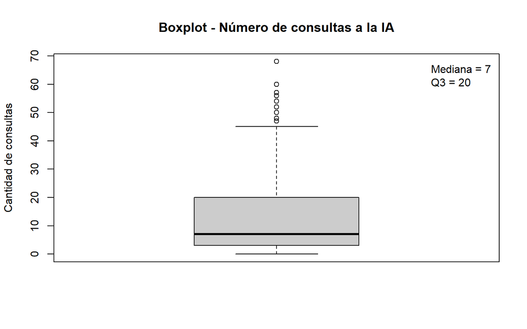

```r
boxplot(DF3$consultas,
        main = "Boxplot - Número de consultas a la IA",
        ylab = "Cantidad de consultas",
        col = "gray80")
legend("topright",
       legend = paste("Mediana =", median(DF3$consultas, na.rm = TRUE), "\nQ3 =", quantile(DF3$consultas, 0.75, na.rm = T, type = 3)), bty = "n")
```

Se puede ver que en al menos la mitad de los registros, el estudiante hace 7 o más consultas diarias a la IA, lo que indica un uso frecuente de esta herramienta. Esto se ve reforzado al notar que, en por lo menos un cuarto de los registros, los estudiantes han hecho 20 o más consultas diarias a la IA.

**Código**

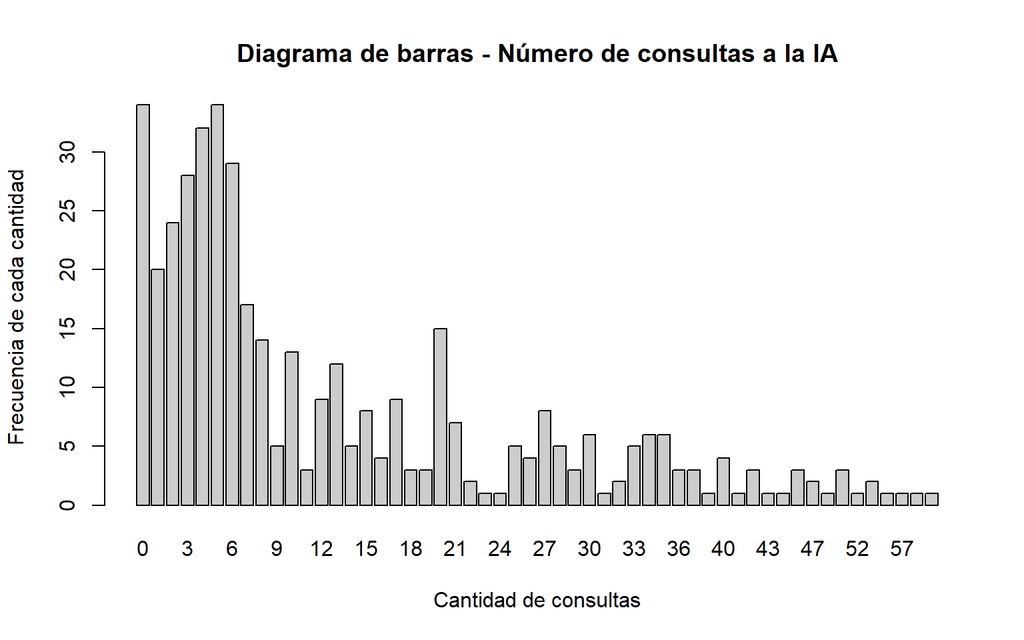

```r
barplot(table(DF3$consultas),
        main = "Diagrama de barras - Número de consultas a la IA",
        xlab = "Cantidad de consultas",
        ylab = "Frecuencia de cada cantidad",
        col = "gray80")
```

### 3.1.2 Nivel de comprensión

Al ser ordinal, usamos frecuencias, porcentajes y barras. No hay media ni desviación porque no son números, pero sí mediana porque tienen orden.

**Código**

```r
table(DF3$comprension)
```

```
Muy bajo     Bajo Moderado     Alto Muy alto
      16       27      237      104       32
```

**Código**

```r
round(prop.table(table(DF3$comprension)) * 100, 2)
```

```
Muy bajo     Bajo Moderado     Alto Muy alto
    3.85     6.49    56.97    25.00     7.69
```

**Código**

```r
round(cumsum(prop.table(table(DF3$comprension))) * 100, 2)
```

```
Muy bajo     Bajo Moderado     Alto Muy alto
    3.85    10.34    67.31    92.31   100.00
```

**Código**

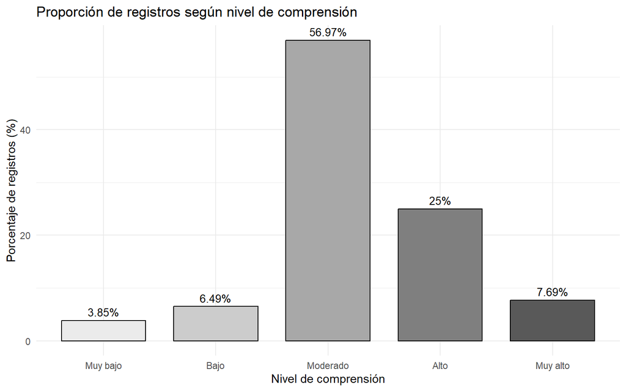

```r
DF3 %>%
  count(comprension) %>%
  mutate(p = n / sum(n) * 100) %>%
  ggplot(aes(x = comprension, y = p, fill = comprension)) +
  geom_col(color = "black", width = 0.75) +
  geom_text(aes(label = paste0(round(p, 2), "%")), vjust = -0.5, size = 3.5) +
  scale_fill_manual(values = c("gray92", "gray80", "gray66", "gray50", "gray35")) +
  labs(title = "Proporción de registros según nivel de comprensión",
       x = "Nivel de comprensión", y = "Porcentaje de registros (%)") +
  theme_minimal() +
  theme(legend.position = "none")
```

### 3.1.3 Horas de sueño

**Código**

```r
summary(DF3$sueno)
```

```
   Min. 1st Qu.  Median    Mean 3rd Qu.    Max.
  0.000   6.000   7.000   6.771   8.000  14.000
```

**Código**

```r
round(sd(DF3$sueno),2)
```

```
[1] 1.96
```

**Código**

```r
IQR(DF3$sueno)
```

```
[1] 2
```

**Código**

```r
round(sd(DF3$sueno) / mean(DF3$sueno),2) #CV
```

```
[1] 0.29
```

**Código**

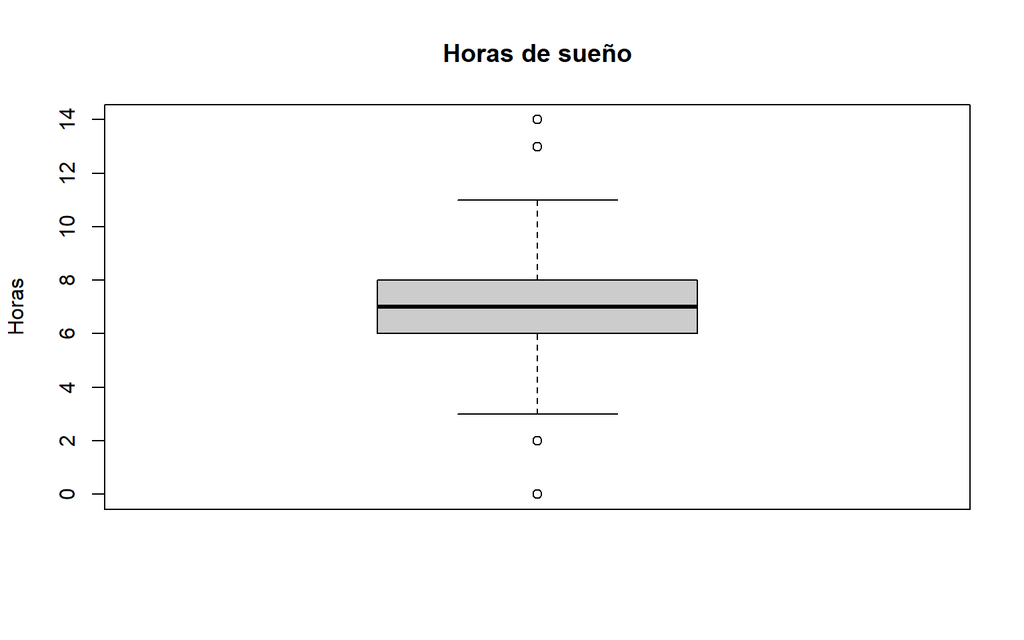

```r
boxplot(DF3$sueno,
        main = "Horas de sueño",
        ylab = "Horas",
        col = "gray80")
```

La variable `sueno` muestra un patrón equilibrado entre los estudiantes de UTEC: la mitad duerme 7 horas o menos, y el 50% central concentra su descanso entre las 6 y 8 horas.

**Código**

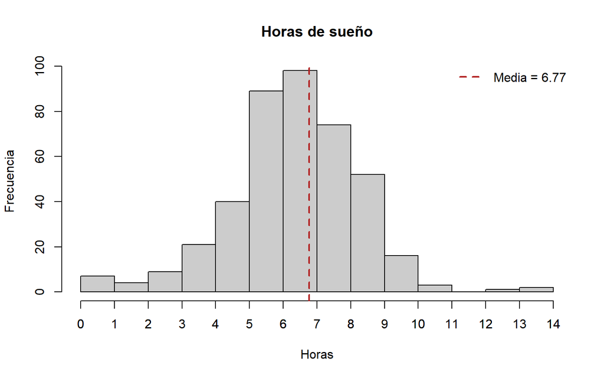

```r
hist(DF3$sueno,
     main = "Horas de sueño",
     xlab = "Horas",
     col = "gray80",
     ylab = "Frecuencia")
axis(1, at = 0:ceiling(max(DF3$sueno)))
abline(v = mean(DF3$sueno, na.rm = TRUE), col = "firebrick", lwd = 2, lty = 2)
legend("topright",
       legend = paste("Media =", round(mean(DF3$sueno, na.rm = TRUE), 2)),
       col = "firebrick", lty = 2, lwd = 2, bty = "n")
```

El histograma confirma ese equilibrio, la mayoría de los estudiantes duerme un número similar de horas, y son pocos los que se alejan bastante del resto.

## 3.2 Análisis de interacción

### 3.2.1 Objetivo 1: consultas vs. satisfacción

**Código**

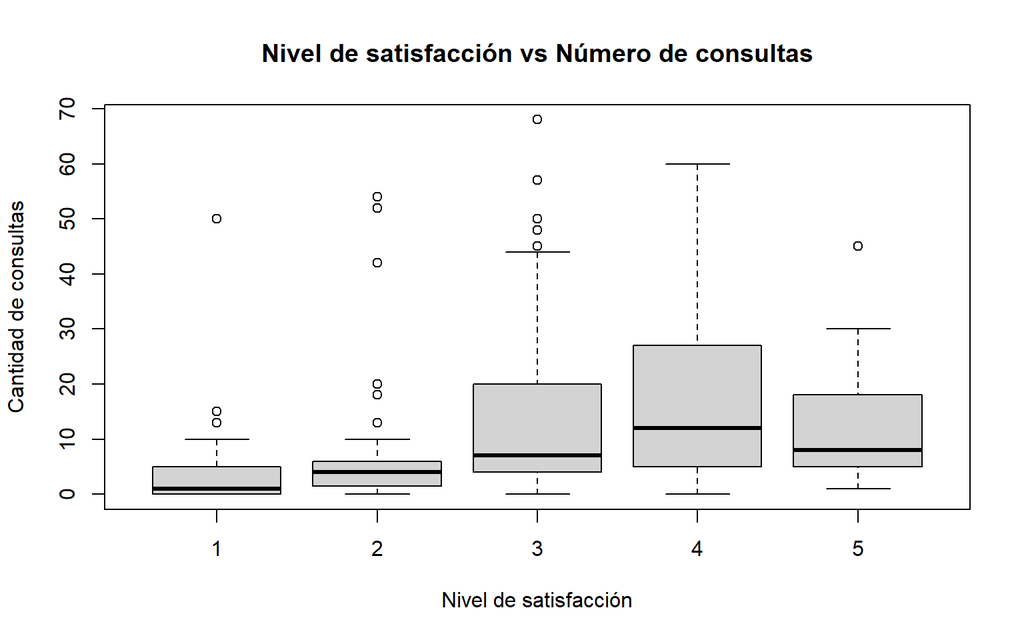

```r
boxplot(consultas ~ satisfaccion, data = DF3,
        main = "Nivel de satisfacción vs Número de consultas",
        xlab = "Nivel de satisfacción",
        ylab = "Cantidad de consultas")
```

Al comparar el nivel de satisfacción de estudio diario con la cantidad de consultas realizadas a la IA, se nota un claro incremento en la mediana de `consultas` de acuerdo al incremento del nivel de satisfacción (excepto en el nivel 5 de satisfacción, donde se ve una disminución de la mediana). Esto nos indica que podría haber una relación importante entre cuántas consultas se han hecho a la IA y cuán satisfecho se está con el estudio de ese día.

**Código**

```r
quantile(DF3$consultas[DF3$satisfaccion == 3], 0.3, na.rm = T, type = 3)
```

```
30%
  4
```

**Código**

```r
quantile(DF3$consultas[DF3$satisfaccion == 4], 0.3, na.rm = T, type = 3)
```

```
30%
  6
```

**Código**

```r
quantile(DF3$consultas[DF3$satisfaccion == 5], 0.3, na.rm = T, type = 3)
```

```
30%
  6
```

Se puede notar que al menos el 70% de los registros de cada categoría de satisfacción “positiva” (3, 4, 5) incluye 4 o más consultas a la IA por día, reforzando la idea de una relación positiva entre `consultas` y `satisfacción`.

### 3.2.2 Objetivo 2: consultas vs. estudio

**Código**

```r
cor.test(DF3$consultas,DF3$estudio,method="spearman")
```

```
    Spearman's rank correlation rho

data:  DF3$consultas and DF3$estudio
S = 5932394, p-value < 2.2e-16
alternative hypothesis: true rho is not equal to 0
sample estimates:
      rho
0.5055712
```

**Código**

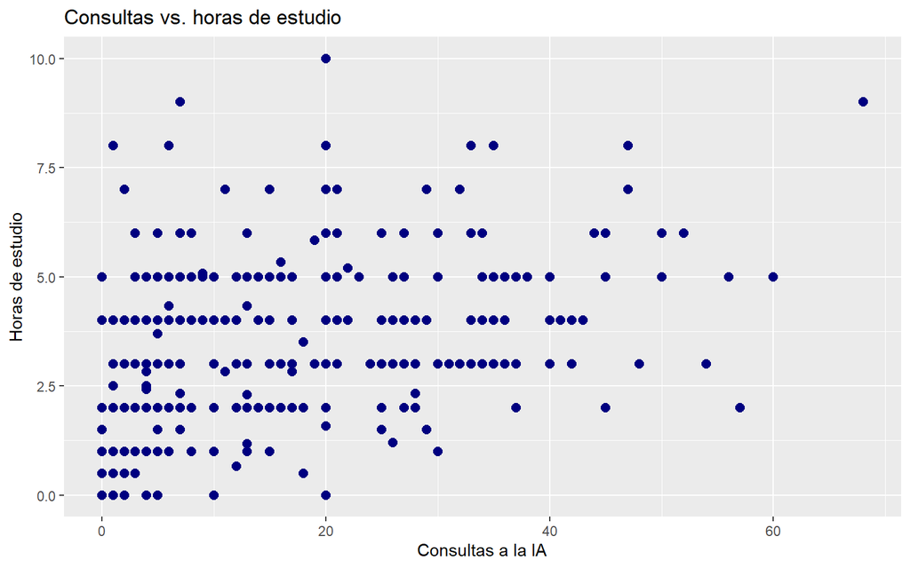

```r
ggplot(DF3, aes(x = consultas, y = estudio)) +
  geom_point(color = "navy", size = 2.5) +
  labs(
    title = "Consultas vs. horas de estudio",
    x = "Consultas a la IA",
    y = "Horas de estudio"
  )
```

### 3.2.3 Objetivo 3a: curso vs. uso

Al ser ambas nominales, usamos tabla cruzada, porcentajes por curso y barras apiladas al 100%. Quitamos los días sin uso de IA y dejamos los 4 cursos y 4 usos más frecuentes.

**Código**

```r
DFC <- DF3[DF3$uso_ia == "Usó IA", ]
DFC$curso <- toupper(DFC$curso)
DFC$uso <- as.character(DFC$uso)
DFC <- DFC[DFC$curso %in% c("CC1105", "CS2031", "CC2101", "CS2013"), ]
DFC <- DFC[DFC$uso %in% c("Resolver ejercicios", "Resumir", "Programar", "Redactar"), ]
nrow(DFC)
```

```
[1] 155
```

**Código**

```r
tabla <- table(DFC$curso, DFC$uso)
tabla
```

```
         Programar Redactar Resolver ejercicios Resumir
  CC1105        23        8                  19       7
  CC2101         1        2                  19       7
  CS2013        12        0                   7       9
  CS2031        21        1                   3      16
```

**Código**

```r
round(prop.table(tabla, 1) * 100, 2)
```

```
         Programar Redactar Resolver ejercicios Resumir
  CC1105     40.35    14.04               33.33   12.28
  CC2101      3.45     6.90               65.52   24.14
  CS2013     42.86     0.00               25.00   32.14
  CS2031     51.22     2.44                7.32   39.02
```

**Código**

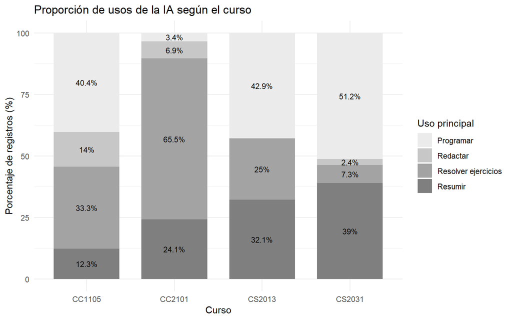

```r
DFC %>%
  count(curso, uso) %>%
  group_by(curso) %>%
  mutate(p = n / sum(n) * 100) %>%
  ggplot(aes(x = curso, y = p, fill = uso)) +
  geom_col(width = 0.75) +
  geom_text(aes(label = paste0(round(p, 1), "%")),
            position = position_stack(vjust = 0.5), size = 3) +
  scale_fill_manual(values = c("gray92", "gray78", "gray64", "gray50")) +
  labs(title = "Proporción de usos de la IA según el curso",
       x = "Curso", y = "Porcentaje de registros (%)", fill = "Uso principal") +
  theme_minimal()
```

### 3.2.4 Objetivo 3b: uso vs. tareas

**Código**

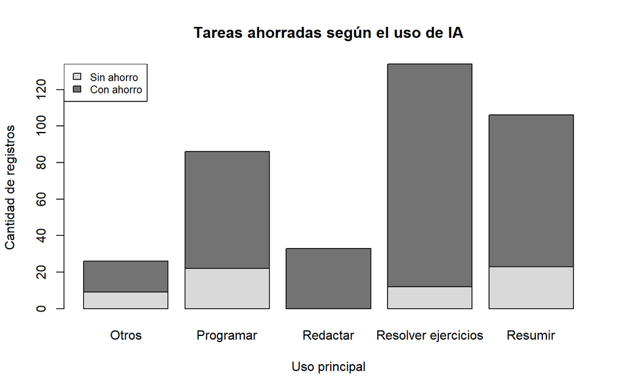

```r
DF3 %>%
  filter(uso_ia == "Usó IA") %>%
  mutate(
    uso_g = if_else(uso %in% c("Resolver ejercicios", "Resumir",
                                "Programar", "Redactar", "No usó IA"),
                     as.character(uso), "Otros"),
    ahorro = if_else(tareas == 0, "Sin tareas ahorradas", "Con tareas ahorradas")
  ) %>%
  count(uso_g, ahorro) %>%
  tidyr::pivot_wider(names_from = ahorro, values_from = n, values_fill = 0) %>%
  {
    tabla <- .[, c("uso_g", "Sin tareas ahorradas", "Con tareas ahorradas")]
    m <- t(as.matrix(tabla[, -1]))
    colnames(m) <- tabla$uso_g
    barplot(m,
            main = "Tareas ahorradas según el uso de IA",
            ylab = "Cantidad de registros",
            xlab = "Uso principal",
            col = c("gray85", "gray45"))
    legend("topleft",
           legend = c("Sin ahorro", "Con ahorro"),
           fill = c("gray85", "gray45"),
           cex = 0.8)
  }
```

**Código**

```r
DF3 %>%
  filter(uso_ia == "Usó IA") %>%
  mutate(uso_g = if_else(uso %in% c("Resolver ejercicios", "Resumir",
                                     "Programar", "Redactar", "No usó IA"),
                          as.character(uso), "Otros")) %>%
  group_by(uso_g) %>%
  summarise(
    registros   = n(),
    ta_ahorrada = round(mean(tareas > 0, na.rm = TRUE) * 100,2),

  ) %>%
  rename(Uso = uso_g)
```

```
# A tibble: 5 × 3
  Uso                 registros ta_ahorrada
  <chr>                   <int>       <dbl>
1 Otros                      26        65.4
2 Programar                  86        74.4
3 Redactar                   33       100
4 Resolver ejercicios       134        91.0
5 Resumir                   106        78.3
```

### 3.2.5 Objetivo 4: comprensión vs. sueño

**Código**

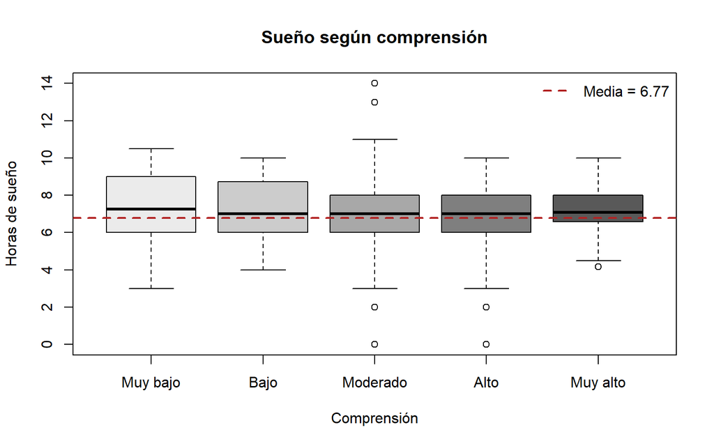

```r
boxplot(sueno ~ comprension, data = DF3,
        main = "Sueño según comprensión",
        xlab = "Comprensión",
        ylab = "Horas de sueño",
        col = c("gray92", "gray80", "gray66", "gray50", "gray35"))
abline(h = mean(DF3$sueno, na.rm = TRUE), col = "firebrick", lwd = 2, lty = 2)
legend("topright",
       legend = paste("Media =", round(mean(DF3$sueno, na.rm = TRUE), 2)),
       col = "firebrick", lty = 2, lwd = 2, bty = "n")
```

**Código**

```r
DF3%>%group_by(comprension)%>% summarise(n=n(),
    Q1= quantile(sueno, 0.25, na.rm = TRUE),
    Mediana = quantile(sueno, 0.5 ,na.rm = TRUE),
    Q3= quantile(sueno, 0.75, na.rm = TRUE),
    RIC     = IQR(sueno, na.rm = TRUE),
    Media = mean(sueno,na.rm=TRUE),
    CV = (sd(sueno,na.rm=TRUE)/mean(sueno,na.rm=TRUE))
                                         )
```

```
# A tibble: 5 × 8
  comprension     n    Q1 Mediana    Q3   RIC Media    CV
  <ord>       <int> <dbl>   <dbl> <dbl> <dbl> <dbl> <dbl>
1 Muy bajo       16  6       7.25  9     3     7.34 0.279
2 Bajo           27  6       7     8.72  2.72  7.35 0.237
3 Moderado      237  6       7     8     2     6.68 0.309
4 Alto          104  6       7     8     2     6.59 0.284
5 Muy alto       32  6.62    7.08  8     1.38  7.29 0.187
```

En Moderado y Alto, que reúnen la mayoría de los registros, el Q1 es 6, la mediana 7 y el Q3 8 horas, es decir, el 50% central duerme entre 6 y 8 horas.

# 4 Análisis Probabilístico

## 4.1 Probabilidad empírica

### 4.1.1 Observaciones limpias del grupo

**Código**

```r
GRUPO <- 6
DF3_grupo <- DF_GesNulos %>% filter(Grupo == GRUPO)
nrow(DF3_grupo)
```

```
[1] 99
```

El Grupo 6 aportó 99 observaciones limpias sobre las 416 de la muestra efectiva de la sección.

### 4.1.2 Variable 1: consultas

Se agrupó esta variable en 5 intervalos por los amplios valores que puede tomar, y estos son sin uso, bajo, moderado, frecuente y muy frecuente, donde sin uso corresponde a cero consultas y muy frecuente no tiene límite superior.

**1. Experimento aleatorio:** $EA_1$: seleccionar al azar un registro de la muestra efectiva y observar el nivel de uso de IA según el número de consultas realizadas ese día.

**2. Espacio de resultados:** $\Omega_{EA_1} = \{\text{Sin uso}, \text{Bajo}, \text{Moderado}, \text{Frecuente}, \text{Muy frecuente}\}$, donde Sin uso $= 0$, Bajo $= [1;10]$, Moderado $= [11;20]$, Frecuente $= [21;30]$ y Muy frecuente $= [31;+\infty\rangle$ consultas.

**3. Eventos atómicos:**

$C_i$: seleccionar un registro al azar cuyo nivel de uso de IA sea el $i$-ésimo de $\Omega_{EA_1}$, con $i = 1, 2, 3, 4, 5$.

**4. Cálculo de probabilidades:**

**Código**

```r
consultas_cat <- cut(DF3$consultas,
                     breaks = c(0, 1, 11, 21, 31, Inf),
                     right = FALSE,
                     labels = c("Sin uso", "Bajo", "Moderado",
                                "Frecuente", "Muy frecuente"))

frec_con <- table(consultas_cat)
prob_con <- prop.table(frec_con)
frec_con
```

```
consultas_cat
      Sin uso          Bajo      Moderado     Frecuente Muy frecuente
           34           216            71            42            53
```

**Código**

```r
round(prob_con, 4)
```

```
consultas_cat
      Sin uso          Bajo      Moderado     Frecuente Muy frecuente
       0.0817        0.5192        0.1707        0.1010        0.1274
```

$P(C_1) = 34/416 = 0.0817$; $P(C_2) = 216/416 = 0.5192$; $P(C_3) = 71/416 = 0.1707$; $P(C_4) = 42/416 = 0.1010$; $P(C_5) = 53/416 = 0.1274$.

**5. Validación:**

**Código**

```r
sum(prob_con)
```

```
[1] 1
```

$0.0817 + 0.5192 + 0.1707 + 0.1010 + 0.1274 = 1$

**Interpretación:**

**Código**

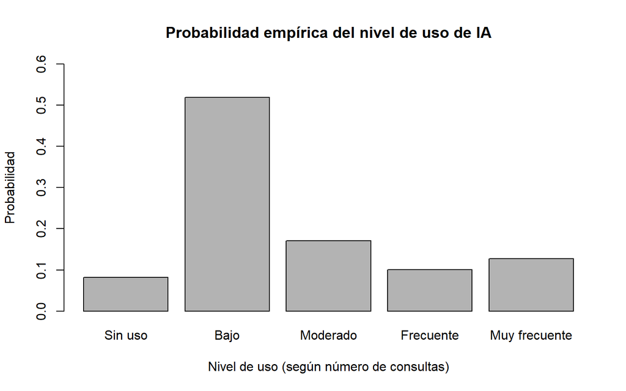

```r
barplot(prob_con,
        main = "Probabilidad empírica del nivel de uso de IA",
        xlab = "Nivel de uso (según número de consultas)",
        ylab = "Probabilidad",
        col = "gray70",
        ylim = c(0, 0.6))
```

El nivel más probable es el bajo, con 0.5192. Las categorías moderado (0.1707), frecuente (0.1010) y muy frecuente (0.1274) se mantienen por debajo de 0.2, y sin uso tiene 0.0817, que corresponde a días sin ninguna consulta a la IA.

### 4.1.3 Variable 2: satisfacción

**1. Experimento aleatorio:** $EA_2$: seleccionar al azar un registro de la muestra efectiva y observar su nivel de satisfacción con el avance académico del día.

**2. Espacio de resultados:** $\Omega_{EA_2} = \{1, 2, 3, 4, 5\}$, donde 1 es muy baja y 5 muy alta.

**3. Eventos atómicos:** $S_i$: seleccionar un registro al azar cuyo nivel de satisfacción sea $i$, con $i = 1, 2, 3, 4, 5$.

**4. Cálculo de probabilidades:**

**Código**

```r
frec_sat <- table(DF3$satisfaccion)
prob_sat <- prop.table(frec_sat)
frec_sat
```

```
  1   2   3   4   5
 30  35 194 125  32
```

**Código**

```r
round(prob_sat, 4)
```

```
     1      2      3      4      5
0.0721 0.0841 0.4663 0.3005 0.0769
```

$P(S_1) = 30/416 = 0.0721$; $P(S_2) = 35/416 = 0.0841$; $P(S_3) = 194/416 = 0.4663$; $P(S_4) = 125/416 = 0.3005$; $P(S_5) = 32/416 = 0.0769$.

**5. Validación:**

**Código**

```r
sum(prob_sat)
```

```
[1] 1
```

$0.0721 + 0.0841 + 0.4663 + 0.3005 + 0.0769 = 1$

**Interpretación:**

**Código**

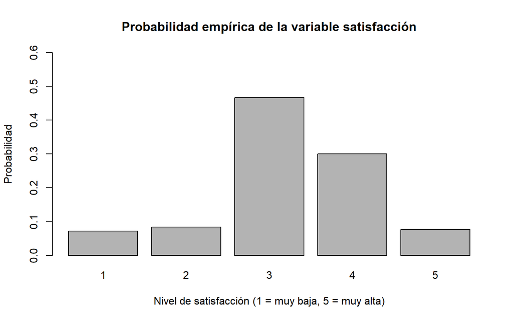

```r
barplot(prob_sat,
        main = "Probabilidad empírica de la variable satisfacción",
        xlab = "Nivel de satisfacción (1 = muy baja, 5 = muy alta)",
        ylab = "Probabilidad",
        col = "gray70",
        ylim = c(0, 0.6))
```

## 4.2 Probabilidad condicional

### 4.2.1 Eventos de interés

Se eligió el rango [5,15] ya que se evita la alta frecuencia que hay en [0,5] y además priorizando una buena cantidad de datos

Vamos a ver la probabilidad del evento A dado el evento B

Evento A : Seleccionar un registro al azar cuyo nivel de comprensión sea de `Alto`.

Evento B : Seleccionar un registro al azar cuyo número de consultas a la IA esté en el rango [5, 15]

**Código**

```r
P_A = nrow(DF3 %>% filter(comprension == "Alto")) / nrow(DF3)
paste("Probabilidad de A:", P_A)
```

```
[1] "Probabilidad de A: 0.25"
```

**Código**

```r
P_B = nrow(DF3 %>% filter(5 <= consultas & consultas <= 15)) / nrow(DF3)
paste("Probabilidad de B:", P_B)
```

```
[1] "Probabilidad de B: 0.358173076923077"
```

**Código**

```r
# Estas graficas son solo referenciales (quitarlas antes de entregar el trabajo)
# barplot(table(DF3$comprension))
# hist(DF3$consultas, breaks = 10)
```

### 4.2.2 Validación de independencia

**Código**

```r
P_A_dado_B = nrow(DF3 %>% filter(5 <= consultas & consultas <= 15 & comprension == "Alto")) / nrow(DF3 %>% filter(5 <= consultas & consultas <= 15))

P_A_dado_B
```

```
[1] 0.2147651
```

**Código**

```r
P_A_inter_B<- nrow(DF3 %>% filter(5 <= consultas & consultas <= 15 & comprension == "Alto")) / nrow(DF3)
round(P_A_inter_B,2) == round(P_A* P_B,2)
```

```
[1] FALSE
```

**Código**

```r
round(P_A_inter_B,3) == round(P_A* P_B,3)
```

```
[1] FALSE
```

**Código**

```r
P_A_dado_B==P_A
```

```
[1] FALSE
```

$P(A \cap B)=0.0769$ y $P(A)\cdot P(B)=0.0895$ $P(A \cap B) \neq P(A) \cdot P(B)$ para la aproximación de 2 y 3 decimales, por lo cual decimos que los eventos son dependientes.

### 4.2.3 Probabilidad condicional y propiedades

**Código**

```r
P_A_U_B<-P_A+P_B-P_A_inter_B
P_A_comp<-1-P_A
P_B_comp<-1-P_B

#leyes de morgan

P_A_U_B_comp<-1-P_A_U_B
P_A_inter_B_comp<-1-P_A_inter_B
P_A_U_B
```

```
[1] 0.53125
```

**Código**

```r
P_A_comp
```

```
[1] 0.75
```

**Código**

```r
P_B_comp
```

```
[1] 0.6418269
```

**Código**

```r
P_A_U_B_comp
```

```
[1] 0.46875
```

**Código**

```r
P_A_inter_B_comp
```

```
[1] 0.9230769
```

Los eventos compuestos son en este caso A union B, interseccion con complemento y union con complemento y ademas tambien se considera A compelmento y B complemento a diferencia de A y B que serian simples

$P(A ∪ B)=0.5312 $ $P(A^C)=0.75$ $P(B^C)=0.6418 $ $P((A ∪ B)^C)=0.4687 $ $P(A ∩ B)^C=0.923$

### 4.2.4 Teorema de Bayes

**Código**

```r
P_B_dado_A = nrow(DF3 %>% filter(5 <= consultas & consultas <= 15 & comprension == "Alto")) / nrow(DF3 %>% filter(comprension == "Alto"))

P_B_dado_A
```

```
[1] 0.3076923
```

**Código**

```r
P_B_dado_noA = nrow(DF3 %>% filter(5 <= consultas & consultas <= 15 & comprension != "Alto")) / nrow(DF3 %>% filter(comprension != "Alto"))

P_B_dado_noA
```

```
[1] 0.375
```

Entonces, el valor obtenido por medio del Teorema de Bayes expandido es:

**Código**

```r
( P_B_dado_A * P_A ) / ( P_B_dado_A * P_A + P_B_dado_noA * P_A_comp)
```

```
[1] 0.2147651
```

Mientras que el resultado del cálculo directo es:

**Código**

```r
P_A_dado_B
```

```
[1] 0.2147651
```

Vemos que los cálculos se realizaron adecuadamente, pues los resultados coinciden.

### 4.2.5 Interpretación en el contexto del estudio

De los resultados del Teorema de Bayes se aprecia que la probabilidad de que el nivel de compresión sea `Alto` dado que la cantidad de consultas a la IA está en el intervalo [5, 15] es de 21.48%. Esto indicaría que es más probable obtener un nivel de comprensión distinto de `Alto` cuando se utiliza un número de consultas contenido en el rango [5, 15].

**Código**

```r
# round(P_A_dado_B * 100, 2)
```

# 5 Conclusiones

## 5.1 Conclusión del Objetivo 1

Como se ha mencionado anteriormente, existe una relación positiva entre el número de consultas a la IA y el grado de satisfacción en el intervalo [1, 4]. Se propone la explicación de que esta relación se podría deber a que un mayor número de consultas ayuda al estudiante a comprender mejor los temas que estudia. Esto derivaría en un mayor grado de satisfacción con el avance académico. Considerando los resultados de la probabilidad condicional calculada, se podría especular que esta mejora en el nivel de comprensión, aunque presente, no sería suficiente para que el estudiante perciba un nivel de comprensión `Alto` en sus estudios. Para el grado de satisfacción 5, si bien no sigue la tendencia de mediana creciente, aún tiene una relación con la variable `consultas` pues al menos el 70% de sus registros reportan por lo menos 5 consultas a la IA por día.

Cabe aclarar que la propuesta de explicación presentada, la cual sigue un formato causa-consecuencia, es solo una hipótesis pues una relación entre variables no implica causalidad.

## 5.2 Conclusión del Objetivo 2

Se comprobó la asociación entre consultas y horas de estudio, la cual es positiva y moderada. Esto sugiere que los días con más horas de estudio tienden a tener más consultas, sin que ello implique causalidad.

## 5.5 Conclusión de probabilidad

Después de limpiar los datos, vimos que los estudiantes de Estadística sección 1 usan la IA casi todos los días y para cosas distintas según el curso. Los que hacen más consultas suelen estudiar más horas y sentirse más satisfechos con su avance. En cambio, las horas de sueño casi no cambian según el nivel de comprensión. Esto no prueba que una cosa cause la otra, solo que suelen darse juntas.